# HE plot MANOVA Examples

Michael Friendly

2026-10-04

Vignette built using `heplots`, version 1.8.6 and `candisc`, version 1.1.1.

# Multivariate Analysis of Variance Designs

This vignette provides some worked examples of the analysis of multivariate linear models (MLMs) for MANOVA designs where all predictors are factors, and the goal is to determine how the group means differ on several response variables in relation to the factors and possible interactions.

Graphical methods for visualizing results using the `heplots` and the `candisc` packages are illustrated. The emphasis here is on using these methods in R, and understanding how they help reveal aspects of these models that might not be apparent from other graphical displays.

No attempt is made here to describe the theory of MLMs or the statistical details behind HE plots and their reduced-rank canonical cousins. For that, see Fox, Friendly, & Monette (2009); Friendly (2007); Friendly (2006).

# 1 Adolescent Mental Health Data

This is a simple example of a one-way MANOVA design with a quantitative factor. The dataset, `AddHealth`, contains a large cross-sectional sample of participants from grades 7–12 from the National Longitudinal Study of Adolescent Health, described by Warne (2014). It contains responses to two Likert-scale (1–5) items, `anxiety` and `depression`. `grade` is an *ordered* factor, which means that the default contrasts are taken as orthogonal polynomials with linear (`grade.L`), quadratic (`grade.Q`), up to 5th degree (`grade^5`) trends, which decompose the total effect of grade.

```r
data(AddHealth, package="heplots")
str(AddHealth)
```

```
#> 'data.frame':    4344 obs. of  3 variables:
#>  $ grade     : Ord.factor w/ 6 levels "7"<"8"<"9"<"10"<..: 5 4 6 1 2 2 2 3 3 3 ...
#>  $ depression: int  0 0 0 0 0 0 0 0 1 2 ...
#>  $ anxiety   : int  0 0 0 1 1 0 0 1 1 0 ...
```

The research questions are:

1. How do the means for anxiety and depression vary separately with grade? Is there evidence for linear and nonlinear trends?
2. How do anxiety and depression vary *jointly* with grade?
3. How does the association of anxiety and depression vary with age?

The first question can be answered by fitting separate linear models for each response (e.g., `lm(anxiety ~ grade))`). However the second question is more interesting because it considers the two responses together and takes their correlation into account. This would be fit as the MLM:

$$\mathbf{y} = \boldsymbol{\beta}_0 + \boldsymbol{\beta}_1 x + \boldsymbol{\beta}_2 x^2 + \cdots \boldsymbol{\beta}_5 x^5
\tag{1.1}$$
or,
$$\begin{bmatrix} y_{\text{anx}} \\y_{\text{dep}} \end{bmatrix} =
\begin{bmatrix} \beta_{0,\text{anx}} \\ \beta_{0,\text{dep}} \end{bmatrix} +
\begin{bmatrix} \beta_{1,\text{anx}} \\ \beta_{1,\text{dep}} \end{bmatrix} \text{grade} +
\begin{bmatrix} \beta_{2,\text{anx}} \\ \beta_{2,\text{dep}} \end{bmatrix} \text{grade}^2 + \cdots
\begin{bmatrix} \beta_{5,\text{anx}} \\ \beta_{5,\text{dep}} \end{bmatrix} \text{grade}^5$$

Using `lm()` we get the coefficients for each of the polynomial terms in `grade`:

```r
lm(cbind(anxiety, depression) ~ grade, data=AddHealth)
```

```
#>
#> Call:
#> lm(formula = cbind(anxiety, depression) ~ grade, data = AddHealth)
#>
#> Coefficients:
#>              anxiety   depression
#> (Intercept)   0.94286   1.18437
#> grade.L       0.32072   0.38917
#> grade.Q      -0.02662  -0.12256
#> grade.C      -0.03979  -0.00952
#> grade^4      -0.02458  -0.04024
#> grade^5      -0.06263  -0.00239
```

## Exploratory plots

Some exploratory analysis is useful before fitting and visualizing models. As a first step, find the means, standard deviations, and standard errors of the means:

```r
library(ggplot2)
library(dplyr)
library(patchwork)

means <- AddHealth |>
  group_by(grade) |>
  summarise(
    n = n(),
    dep_sd = sd(depression, na.rm = TRUE),
    anx_sd = sd(anxiety, na.rm = TRUE),
    dep_se = dep_sd / sqrt(n),
    anx_se = anx_sd / sqrt(n),
    depression = mean(depression),
    anxiety = mean(anxiety) ) |>
  relocate(depression, anxiety, .after = grade) |>
  print()
```

```
#> # A tibble: 6 × 8
#>   grade depression anxiety     n dep_sd anx_sd dep_se anx_se
#>   <ord>      <dbl>   <dbl> <int>  <dbl>  <dbl>  <dbl>  <dbl>
#> 1 7          0.881   0.751   622   1.11   1.05 0.0447 0.0420
#> 2 8          1.08    0.804   664   1.19   1.06 0.0461 0.0411
#> 3 9          1.17    0.934   778   1.19   1.08 0.0426 0.0387
#> 4 10         1.27    0.956   817   1.23   1.11 0.0431 0.0388
#> 5 11         1.37    1.12    790   1.20   1.16 0.0428 0.0411
#> 6 12         1.34    1.10    673   1.14   1.11 0.0439 0.0426
```

Now, plot the means with $\pm 1$ error bars. It appears that average level of both depression and anxiety increase steadily with grade, except for grades 11 and 12 which don’t differ much.

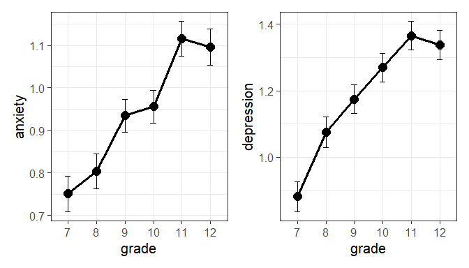

Figure 1.1: Means of anxiety and depression by grade, with $\pm 1$ standard error bars.

```r
p1 <-ggplot(data = means, aes(x = grade, y = anxiety)) +
  geom_point(size = 4) +
  geom_line(aes(group = 1), linewidth = 1.2) +
  geom_errorbar(aes(ymin = anxiety - anx_se,
                   ymax = anxiety + anx_se),
                width = .2) +
  theme_bw(base_size = 15)

p2 <-ggplot(data = means, aes(x = grade, y = depression)) +
  geom_point(size = 4) +
  geom_line(aes(group = 1), linewidth = 1.2) +
  geom_errorbar(aes(ymin = depression - dep_se,
                    ymax = depression + dep_se),
                width = .2) +
  theme_bw(base_size = 15)

p1 + p2
```

Treating anxiety and depression as multivariate outcomes, we can also plot their bivariate means.

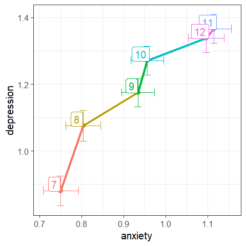

Figure 1.2: Joint plot of means of anxiety and depression by grade, with $\pm 1$ standard error bars.

```r
ggplot(data = means, aes(x = anxiety, y = depression,
                         color = grade)) +
  geom_point(size = 3) +
  geom_errorbarh(aes(xmin = anxiety - anx_se,
                    xmax = anxiety + anx_se)) +
  geom_errorbar(aes(ymin = depression - dep_se,
                    ymax = depression + dep_se)) +
  geom_line(aes(group = 1), linewidth = 1.5) +
  geom_label(aes(label = grade),
             nudge_x = -0.015, nudge_y = 0.02) +
  scale_color_discrete(guide = "none") +
  theme_bw(base_size = 15)
```

You can examine the within-group correlations using `covEllipses()`. Because the variability of the scores is so large compared to the range of the means, I show the data ellipses with coverage of only 10%.

```r
covEllipses(AddHealth[, 3:2], group = AddHealth$grade,
            pooled = FALSE, level = 0.1,
            center.cex = 2.5, cex = 1.5, cex.lab = 1.5,
            fill = TRUE, fill.alpha = 0.05)
```

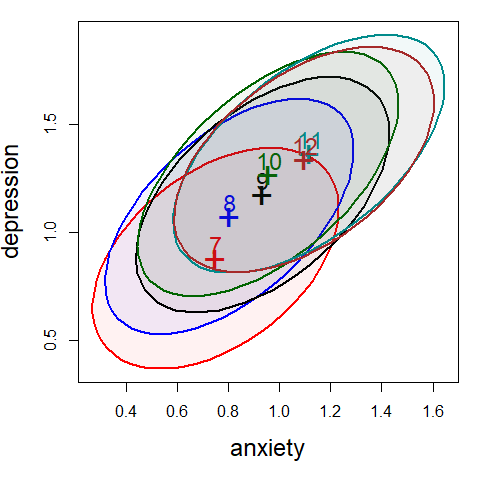

Figure 1.3: Within-group covariance ellipses for the `grade` groups.

## Fit the MLM

Now, let’s fit the MLM for both responses jointly in relation to `grade`. The null hypothesis is that the means for anxiety and depression are the same at all six grades,
$$H_0 : \mathbf{\mu}_7 = \mathbf{\mu}_8 = \cdots = \mathbf{\mu}_{12} \; ,$$
or equivalently, that all coefficients except the intercept in the model (1.1) are zero,
$$H_0 : \boldsymbol{\beta}_1 = \boldsymbol{\beta}_2 = \cdots = \boldsymbol{\beta}_5 = \boldsymbol{0} \; .$$

The overall test, with 5 degrees of freedom is diffuse, in that it can be rejected if any pair of means differ.

`car::Anova()` gives a simple display of the multivariate test, using the Pillai trace criterion.

```r
AH.mlm <- lm(cbind(anxiety, depression) ~ grade, data = AddHealth)

# overall test of `grade`
Anova(AH.mlm)
```

```
#>
#> Type II MANOVA Tests: Pillai test statistic
#>       Df test stat approx F num Df den Df Pr(>F)
#> grade  5    0.0224     9.83     10   8676 <2e-16 ***
#> ---
#> Signif. codes:  0 '***' 0.001 '**' 0.01 '*' 0.05 '.' 0.1 ' ' 1
```

The `summary()` method for this gives all four test statistics.

```r
## show separate multivariate tests
summary(Anova(AH.mlm)) |> print(SSP = FALSE)
```

```
#>
#> Type II MANOVA Tests:
#>
#> ------------------------------------------
#>
#> Term: grade
#>
#> Multivariate Tests: grade
#>                  Df test stat approx F num Df den Df    Pr(>F)
#> Pillai            5   0.02242   9.8340     10   8676 < 2.2e-16 ***
#> Wilks             5   0.97762   9.8726     10   8674 < 2.2e-16 ***
#> Hotelling-Lawley  5   0.02286   9.9112     10   8672 < 2.2e-16 ***
#> Roy               5   0.02119  18.3878      5   4338 < 2.2e-16 ***
#> ---
#> Signif. codes:  0 '***' 0.001 '**' 0.01 '*' 0.05 '.' 0.1 ' ' 1
```

## Testing linear hypotheses

Given that `grade` is an ordered factor, it makes sense to examine narrower hypotheses of linear and nonlinear trends. `car::linearHypothesis()` provides a general way to do this, giving multivariate tests for one or more linear combinations of coefficients.

The joint test of the linear coefficients for anxiety and depression, $H_0 : \boldsymbol{\beta}_1 = \boldsymbol{0}$ is highly significant,

```r
## linear effect
linearHypothesis(AH.mlm, "grade.L") |> print(SSP = FALSE)
```

```
#>
#> Multivariate Tests:
#>                  Df test stat approx F num Df den Df    Pr(>F)
#> Pillai            1   0.01921   42.479      2   4337 < 2.2e-16 ***
#> Wilks             1   0.98079   42.479      2   4337 < 2.2e-16 ***
#> Hotelling-Lawley  1   0.01959   42.479      2   4337 < 2.2e-16 ***
#> Roy               1   0.01959   42.479      2   4337 < 2.2e-16 ***
#> ---
#> Signif. codes:  0 '***' 0.001 '**' 0.01 '*' 0.05 '.' 0.1 ' ' 1
```

The test of the quadratic coefficients $H_0 : \boldsymbol{\beta}_2 = \boldsymbol{0}$ indicates significant curvature in trends across grade, as we saw in the plots of their means, Figures 1.1 and 1.2.

```r
## quadratic effect
linearHypothesis(AH.mlm, "grade.Q") |> print(SSP = FALSE)
```

```
#>
#> Multivariate Tests:
#>                  Df test stat approx F num Df den Df  Pr(>F)
#> Pillai            1   0.00195   4.2421      2   4337 0.01444 *
#> Wilks             1   0.99805   4.2421      2   4337 0.01444 *
#> Hotelling-Lawley  1   0.00196   4.2421      2   4337 0.01444 *
#> Roy               1   0.00196   4.2421      2   4337 0.01444 *
#> ---
#> Signif. codes:  0 '***' 0.001 '**' 0.01 '*' 0.05 '.' 0.1 ' ' 1
```

We can also test the hypothesis that all higher order terms beyond the quadratic are zero, $H_0 : \boldsymbol{\beta}_3 = \boldsymbol{\beta}_4 = \boldsymbol{\beta}_5 = \boldsymbol{0}$:

```r
## joint test of all higher terms
linearHypothesis(AH.mlm, rownames(coef(AH.mlm))[3:5]) |> print(SSP = FALSE)
```

```
#>
#> Multivariate Tests:
#>                  Df test stat approx F num Df den Df  Pr(>F)
#> Pillai            3   0.00235   1.7021      6   8676 0.11612
#> Wilks             3   0.99765   1.7023      6   8674 0.11608
#> Hotelling-Lawley  3   0.00236   1.7025      6   8672 0.11604
#> Roy               3   0.00206   2.9797      3   4338 0.03022 *
#> ---
#> Signif. codes:  0 '***' 0.001 '**' 0.01 '*' 0.05 '.' 0.1 ' ' 1
```

## HE plot

You can include any linear hypotheses or contrasts using the `hypotheses` argument. The **H** ellipses for the 1 df linear and quadratic terms plot as lines. The linear effect corresponds to the major axis of the **H** ellipse for the `grade` effect.

Again, to preserve resolution in the plot, I show the **H** and **E** ellipses with only 10% coverage, but it is only the relative size of an **H** ellipse relative to **E** that matters: With the default significance scaling, any effect is significant *iff* the corresponding **H** ellipsoid projects anywhere outside the **E** ellipsoid in the space of all the responses. In a 2D plot, **H** outside **E** therefore means the effect is significant, but **H** inside **E** does not mean it is not: the effect may lie in directions not shown in that view.

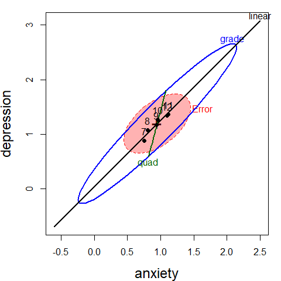

Figure 1.4: HE plot for the multivariate model `AH.mlm`, showing the overall effect of `grade` as well as tests for the linear and quadratic terms in this model.

```r
heplot(AH.mlm,
       hypotheses = c("grade.L", "grade.Q"),
       hyp.labels = c("linear", "quad"),
       label.pos = c(4, 3, 1, 1),
       fill=c(TRUE, FALSE),
       level = 0.1,
       cex.lab = 1.5)
```

# 2 Plastic film data

An experiment was conducted to determine the optimum conditions for extruding plastic film. Three responses, `tear` resistance, film `gloss` and film `opacity` were measured in relation to two factors, `rate` of extrusion and amount of an `additive`, both of these being set to two values, High and Low. The data set comes from Johnson & Wichern (1992).

```r
data(Plastic, package="heplots")
str(Plastic)
```

```
#> 'data.frame':    20 obs. of  5 variables:
#>  $ tear    : num  6.5 6.2 5.8 6.5 6.5 6.9 7.2 6.9 6.1 6.3 ...
#>  $ gloss   : num  9.5 9.9 9.6 9.6 9.2 9.1 10 9.9 9.5 9.4 ...
#>  $ opacity : num  4.4 6.4 3 4.1 0.8 5.7 2 3.9 1.9 5.7 ...
#>  $ rate    : Factor w/ 2 levels "Low","High": 1 1 1 1 1 1 1 1 1 1 ...
#>  $ additive: Factor w/ 2 levels "Low","High": 1 1 1 1 1 2 2 2 2 2 ...
```

The design is thus a $2\times 2$ MANOVA, with $n=5$ per cell and 3 numeric response variables. Because the effects of the factors on the responses are likely correlated, it is useful to consider a multivariate analysis, rather than 3 separate univariate ones.

This example illustrates:

- 2D and 3D HE plots,
- the difference between “effect” scaling and “evidence” (significance) scaling, and
- visualizing composite linear hypotheses.

## Multivariate tests

We begin with an overall MANOVA for the two-way MANOVA model. In all these analyses, we use `car::Anova()` for significance tests rather than `stats::anova()`, which only provides so-called “Type I” (sequential) tests for terms in linear models.

In this example, because each effect has 1 df, all of the multivariate statistics (Roy’s maximum root test, Pillai and Hotelling trace criteria, Wilks’ Lambda) are equivalent, in that they give the same $F$ statistics and $p$-values. We specify `test.statistic="Roy"` to emphasize that Roy’s test has a natural visual interpretation in HE plots.

```r
plastic.mod <- lm(cbind(tear, gloss, opacity) ~ rate*additive, data=Plastic)
Anova(plastic.mod, test.statistic="Roy")
```

```
#>
#> Type II MANOVA Tests: Roy test statistic
#>               Df test stat approx F num Df den Df Pr(>F)
#> rate           1     1.619     7.55      3     14  0.003 **
#> additive       1     0.912     4.26      3     14  0.025 *
#> rate:additive  1     0.287     1.34      3     14  0.302
#> ---
#> Signif. codes:  0 '***' 0.001 '**' 0.01 '*' 0.05 '.' 0.1 ' ' 1
```

For the three responses jointly, the main effects of `rate` and `additive` are significant, while their interaction is not. In some approaches to testing effects in multivariate linear models (MLMs), significant multivariate tests are often followed by univariate tests on each of the responses separately to determine which responses contribute to each significant effect.

In R, univariate analyses are conveniently performed using the `update()` method for the `mlm` object `plastic.mod`, which re-fits the model with only a single outcome variable.

```r
Anova(update(plastic.mod, tear ~ .))
```

```
#> Anova Table (Type II tests)
#>
#> Response: tear
#>               Sum Sq Df F value Pr(>F)
#> rate            1.74  1    15.8 0.0011 **
#> additive        0.76  1     6.9 0.0183 *
#> rate:additive   0.00  1     0.0 0.9471
#> Residuals       1.76 16
#> ---
#> Signif. codes:  0 '***' 0.001 '**' 0.01 '*' 0.05 '.' 0.1 ' ' 1
```

```r
Anova(update(plastic.mod, gloss ~ .))
```

```
#> Anova Table (Type II tests)
#>
#> Response: gloss
#>               Sum Sq Df F value Pr(>F)
#> rate           1.301  1    7.92  0.012 *
#> additive       0.612  1    3.73  0.071 .
#> rate:additive  0.544  1    3.32  0.087 .
#> Residuals      2.628 16
#> ---
#> Signif. codes:  0 '***' 0.001 '**' 0.01 '*' 0.05 '.' 0.1 ' ' 1
```

```r
Anova(update(plastic.mod, opacity ~ .))
```

```
#> Anova Table (Type II tests)
#>
#> Response: opacity
#>               Sum Sq Df F value Pr(>F)
#> rate             0.4  1    0.10   0.75
#> additive         4.9  1    1.21   0.29
#> rate:additive    4.0  1    0.98   0.34
#> Residuals       64.9 16
```

The results above show significant main effects for `tear`, a significant main effect of `rate` for `gloss`, and no significant effects for `opacity`, but they don’t shed light on the *nature* of these effects. Traditional univariate plots of the means for each variable separately are useful, but they don’t allow visualization of the *relations* among the response variables.

## HE plots

We can visualize these effects for pairs of variables in an HE plot, showing the “size” and orientation of hypothesis variation ($\mathbf{H}$) in relation to error variation ($\mathbf{E}$) as ellipsoids. When, as here, the model terms have 1 degree of freedom, the $\mathbf{H}$ ellipsoids degenerate to a line.

In HE plots, the $\mathbf{H}$ ellipses can be scaled relative to the $\mathbf{E}$ to show **significance** of effects (`size="evidence"`), or **effect size** (`size="effect"`). In the former case, a model term is significant (using Roy’s maximum root test) *iff* the $\mathbf{H}$ ellipsoid projects anywhere outside the $\mathbf{E}$ ellipsoid in the full space of the responses. In a particular 2D view, this works one way only, as the next example shows.

This plot overlays those for both scaling, using thicker lines for the effect scaling.

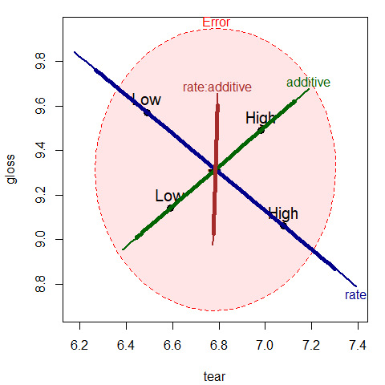

Figure 2.1: HE plot for effects on `tear` and `gloss` according to the factors `rate`, `additive` and their interaction, `rate:additive`. The thicker lines show effect size scaling; the thinner lines show significance scaling.

```r
## Compare evidence and effect scaling
colors = c("red", "darkblue", "darkgreen", "brown")
heplot(plastic.mod, size="evidence",
       col=colors, cex=1.25,
       fill=TRUE, fill.alpha=0.1)
heplot(plastic.mod, size="effect",
       add=TRUE, lwd=5, term.labels=FALSE, col=colors)
```

The interpretation can be easily read from the plot, at least for the two response variables (`tear` and `gloss`) that are shown in this bivariate view. The effect of `rate` of extrusion is highly significant: high rate shows greater `tear` compared to low rate. The effect of amount of additive is not significant in this view, but high level of additive has greater `tear` and `gloss`.

With effect scaling, both the $\mathbf{H}$ and $\mathbf{E}$ sums of squares and products matrices are both divided by the error df, giving multivariate analogs of univariate measures of effect size, e.g., $(\bar{y}_1-\bar{y}_2) / s$. With significance scaling, the $\mathbf{H}$ ellipse is further divided by $\lambda_\alpha$, the critical value of Roy’s largest root statistic. This scaling has the property that an $\mathbf{H}$ ellipsoid will protrude somewhere outside the $\mathbf{E}$ ellipsoid in the full space of the responses *iff* the multivariate test is significant at level $\alpha$. Figure 2.2 shows both scalings, using a thinner line for significance scaling. Note that the (degenerate) ellipse for `additive` is significant ($p = .025$), but does not protrude outside the $\mathbf{E}$ ellipse in this view, nor in either of the other two pairwise views of the responses. All that is guaranteed is that it will protrude somewhere in the 3D space of the responses (Figure 2.4).

So, in any 2D (or 3D) view, the rule works in one direction only: if an $\mathbf{H}$ ellipse extends outside $\mathbf{E}$, the effect is significant; but if it lies inside $\mathbf{E}$, the effect may still be significant in some direction not shown. To check, look at other views (`pairs()`, `heplot3d()`), a canonical view (`candisc::heplot()`), where the directions of largest effect are shown, or the tests from `car::Anova()`.

By design, means for the levels of interaction terms are not shown in the HE plot, because doing so in general can lead to messy displays. We can add them here for the term `rate:additive` as follows:

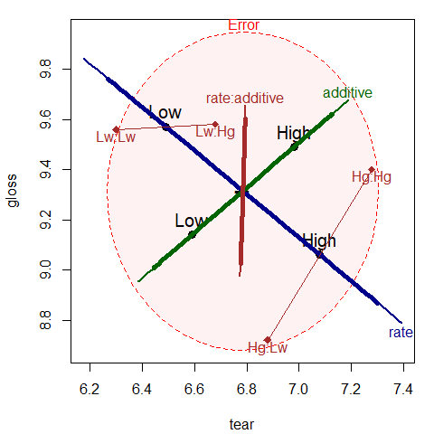

Figure 2.2: HE plot for effects on `tear` and `gloss` according to the factors `rate`, `additive` and their interaction, `rate:additive`. Annotations have added means for the combinations of `rate` and `additive`.

```r
# Compare evidence and effect scaling
colors = c("red", "darkblue", "darkgreen", "brown")
heplot(plastic.mod, size="evidence",
       col=colors, cex=1.25,
       fill=TRUE, fill.alpha=0.05)
heplot(plastic.mod, size="effect",
       add=TRUE, lwd=5, term.labels=FALSE, col=colors)

## add interaction means
intMeans <- termMeans(plastic.mod, 'rate:additive', abbrev.levels=2)
points(intMeans[,1], intMeans[,2], pch=18, cex=1.2, col="brown")
text(intMeans[,1], intMeans[,2], rownames(intMeans),
     adj=c(0.5, 1), col="brown")
lines(intMeans[c(1,3),1], intMeans[c(1,3),2], col="brown")
lines(intMeans[c(2,4),1], intMeans[c(2,4),2], col="brown")
```

The factor means in this plot (Figure 2.2 have a simple interpretation: The high `rate` level yields greater `tear` resistance but lower `gloss` than the low level. The high `additive` amount produces greater `tear` resistance and greater `gloss`.

The `rate:additive` interaction is not significant overall, though it approaches significance for `gloss`. The cell means for the combinations of `rate` and `additive` shown in this figure suggest an explanation, for tutorial purposes: with the low level of `rate`, there is little difference in `gloss` for the levels of `additive`. At the high level of `rate`, there is a larger difference in `gloss`. The $\mathbf{H}$ ellipse for the interaction of `rate:additive` therefore “points” in the direction of `gloss` indicating that this variable contributes to the interaction in the multivariate tests.

In some MANOVA models, it is of interest to test sub-hypotheses of a given main effect or interaction, or conversely to test composite hypotheses that pool together certain effects to test them jointly. All of these tests (and, indeed, the tests of terms in a given model) are carried out as tests of general linear hypotheses in the MLM.

In this example, it might be useful to test two composite hypotheses: one corresponding to both main effects jointly, and another corresponding to no difference among the means of the four groups (equivalent to a joint test for the overall model). These tests are specified in terms of subsets or linear combinations of the model parameters.

```r
plastic.mod
```

```
#>
#> Call:
#> lm(formula = cbind(tear, gloss, opacity) ~ rate * additive, data = Plastic)
#>
#> Coefficients:
#>                        tear   gloss  opacity
#> (Intercept)             6.30   9.56   3.74
#> rateHigh                0.58  -0.84  -0.60
#> additiveHigh            0.38   0.02   0.10
#> rateHigh:additiveHigh   0.02   0.66   1.78
```

Thus, for example, the joint test of both main effects tests the parameters `rateHigh` and `additiveHigh`.

```r
linearHypothesis(plastic.mod, c("rateHigh", "additiveHigh"),
                 title="Main effects") |>
  print(SSP=FALSE)
```

```
#>
#> Multivariate Tests: Main effects
#>                  Df test stat approx F num Df den Df   Pr(>F)
#> Pillai            2   0.71161   2.7616      6     30 0.029394 *
#> Wilks             2   0.37410   2.9632      6     28 0.022839 *
#> Hotelling-Lawley  2   1.44400   3.1287      6     26 0.019176 *
#> Roy               2   1.26253   6.3127      3     15 0.005542 **
#> ---
#> Signif. codes:  0 '***' 0.001 '**' 0.01 '*' 0.05 '.' 0.1 ' ' 1
```

```r
linearHypothesis(plastic.mod, c("rateHigh", "additiveHigh", "rateHigh:additiveHigh"),
                 title="Groups") |>
  print(SSP=FALSE)
```

```
#>
#> Multivariate Tests: Groups
#>                  Df test stat approx F num Df den Df   Pr(>F)
#> Pillai            3   1.14560   3.2948      9 48.000 0.003350 **
#> Wilks             3   0.17802   3.9252      9 34.223 0.001663 **
#> Hotelling-Lawley  3   2.81752   3.9654      9 38.000 0.001245 **
#> Roy               3   1.86960   9.9712      3 16.000 0.000603 ***
#> ---
#> Signif. codes:  0 '***' 0.001 '**' 0.01 '*' 0.05 '.' 0.1 ' ' 1
```

Correspondingly, we can display these tests in the HE plot by specifying these tests in the `hypothesis` argument to `heplot()`, as shown in Figure 2.3.

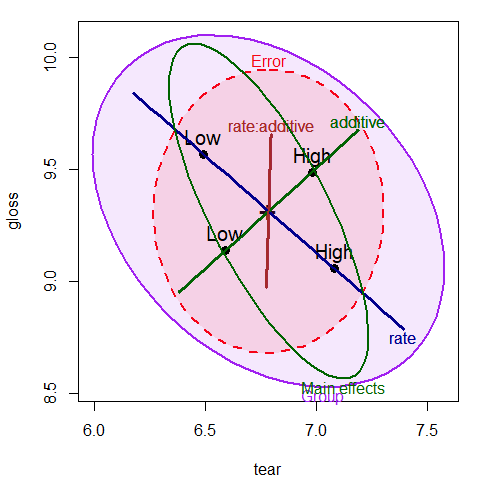

Figure 2.3: HE plot for `tear` and `gloss`, supplemented with ellipses representing the joint tests of main effects and all group differences

```r
heplot(plastic.mod,
       hypotheses=list("Group" =  c("rateHigh", "additiveHigh", "rateHigh:additiveHigh ")),
       col=c(colors, "purple"),
       fill = TRUE, fill.alpha = 0.1,
       lwd=c(2, 3, 3, 3, 2), cex=1.25)
heplot(plastic.mod,
       hypotheses=list("Main effects" = c("rateHigh", "additiveHigh")),
       add=TRUE,
       col=c(colors, "darkgreen"), cex=1.25)
```

Finally, a 3D HE plot can be produced with `heplot3d()`, giving Figure 2.4. This plot was rotated interactively to a view that shows both main effects protruding outside the error ellipsoid.

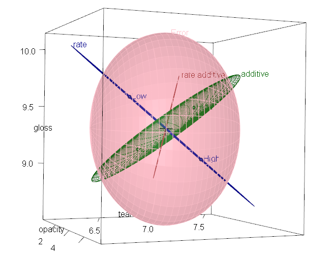

Figure 2.4: 3D HE plot for the plastic MLM

```r
colors = c("pink", "darkblue", "darkgreen", "brown")
heplot3d(plastic.mod, col=colors)
```

# 3 Effects of physical attractiveness on mock jury decisions

In a social psychology study of influences on jury decisions by Plaster (1989), male participants (prison inmates) were shown a picture of one of three young women.  
Pilot work had indicated that one woman was beautiful, another of average physical attractiveness, and the third unattractive. Participants rated the woman they saw on each of twelve attributes on scales of 1–9. These measures were used to check on the manipulation of “attractiveness” by the photo.

Then the participants were told that the person in the photo had committed a Crime, and asked to rate the seriousness of the crime and recommend a prison sentence, in Years. The data are contained in the data frame `MockJury`.[^1]

```r
data(MockJury, package = "heplots")
str(MockJury)
```

```
#> 'data.frame':    114 obs. of  17 variables:
#>  $ Attr         : Factor w/ 3 levels "Beautiful","Average",..: 1 1 1 1 1 1 1 1 1 1 ...
#>  $ Crime        : Factor w/ 2 levels "Burglary","Swindle": 1 1 1 1 1 1 1 1 1 1 ...
#>  $ Years        : int  10 3 5 1 7 7 3 7 2 3 ...
#>  $ Serious      : int  8 8 5 3 9 9 4 4 5 2 ...
#>  $ exciting     : int  6 9 3 3 1 1 5 4 4 6 ...
#>  $ calm         : int  9 5 4 6 1 5 6 9 8 8 ...
#>  $ independent  : int  9 9 6 9 5 7 7 2 8 7 ...
#>  $ sincere      : int  8 3 3 8 1 5 6 9 7 5 ...
#>  $ warm         : int  5 5 6 8 8 8 7 6 1 7 ...
#>  $ phyattr      : int  9 9 7 9 8 8 8 5 9 8 ...
#>  $ sociable     : int  9 9 4 9 9 9 7 2 1 9 ...
#>  $ kind         : int  9 4 2 9 4 5 5 9 5 7 ...
#>  $ intelligent  : int  6 9 4 9 7 8 7 9 9 9 ...
#>  $ strong       : int  9 5 5 9 9 9 5 2 7 5 ...
#>  $ sophisticated: int  9 5 4 9 9 9 6 2 7 6 ...
#>  $ happy        : int  5 5 5 9 8 9 5 2 6 8 ...
#>  $ ownPA        : int  9 7 5 9 7 9 6 5 3 6 ...
```

Sample sizes were roughly balanced for the independent variables in the three conditions of the attractiveness of the photo, and the combinations of this with `Crime`:

```r
table(MockJury$Attr)
```

```
#>
#>    Beautiful      Average Unattractive
#>           39           38           37
```

```r
table(MockJury$Attr, MockJury$Crime)
```

```
#>
#>                Burglary Swindle
#>   Beautiful          21      18
#>   Average            18      20
#>   Unattractive       20      17
```

The main questions of interest were:

- Does attractiveness of the “defendant” influence the sentence or perceived seriousness of the crime?
- Does attractiveness interact with the nature of the crime?

## Manipulation check

But first, as a check on the manipulation of attractiveness, we try to assess the ratings of the photos in relation to the presumed categories of the independent variable `Attr`. The questions here are:

- do the ratings of the photos on physical attractiveness (`phyattr`) confirm the original classification?
- how do other ratings differentiate the photos?

To keep things simple, we consider only a few of the other ratings in a one-way MANOVA.

```r
(jury.mod1 <- lm( cbind(phyattr, happy, independent, sophisticated) ~ Attr, data=MockJury))
```

```
#>
#> Call:
#> lm(formula = cbind(phyattr, happy, independent, sophisticated) ~
#>     Attr, data = MockJury)
#>
#> Coefficients:
#>                   phyattr  happy   independent  sophisticated
#> (Intercept)        8.282    5.359   6.410        6.077
#> AttrAverage       -4.808    0.430   0.537       -1.340
#> AttrUnattractive  -5.390   -1.359  -1.410       -1.753
```

```r
Anova(jury.mod1, test="Roy")
```

```
#>
#> Type II MANOVA Tests: Roy test statistic
#>      Df test stat approx F num Df den Df Pr(>F)
#> Attr  2      1.77     48.2      4    109 <2e-16 ***
#> ---
#> Signif. codes:  0 '***' 0.001 '**' 0.01 '*' 0.05 '.' 0.1 ' ' 1
```

Note that `Beautiful` is the baseline category of `Attr`, so the intercept term gives the means for this level. We see that the means are significantly different on all four variables collectively, by a joint multivariate test. A traditional analysis might follow up with univariate ANOVAs for each measure separately.

As an aid to interpretation of the MANOVA results We can examine the test of `Attr` in this model with an HE plot for pairs of variables, e.g., for `phyattr` and `happy` (Figure 3.1). The means in this plot show that Beautiful is rated higher on physical attractiveness than the other two photos, while Unattractive is rated less happy than the other two. Comparing the sizes of the ellipses, differences among group means on physical attractiveness contributes more to significance than do ratings on happy.

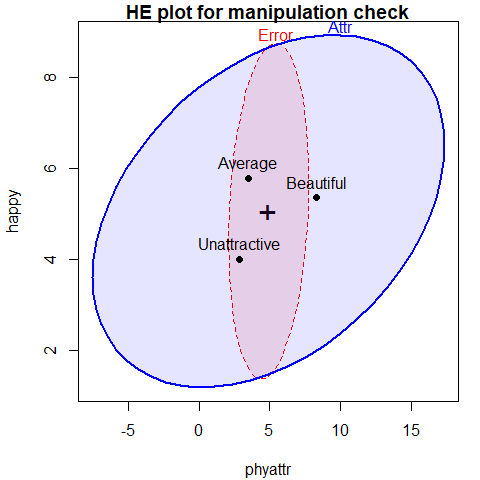

Figure 3.1: HE plot for ratings of `phyattr` and `happy` according to the classification of photos on `Attr`

```r
heplot(jury.mod1, main="HE plot for manipulation check",
       fill = TRUE, fill.alpha = 0.1)
```

The function `pairs.mlm()` produces all pairwise HE plots. This plot (Figure 3.2) shows that the means for `happy` and `independent` are highly correlated, as are the means for `phyattr` and `sophisticated`. In most of these pairwise plots, the means form a triangle rather than a line, suggesting that these attributes are indeed measuring different aspects of the photos.

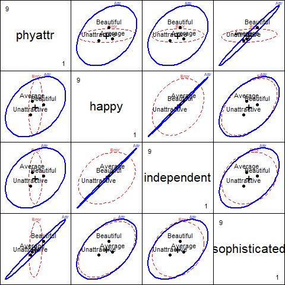

Figure 3.2: HE plots for all pairs of ratings according to the classification of photos on `Attr`

```r
pairs(jury.mod1)
```

These relations among three of the variables, `phyattr`, `independent` and `sophisticated`, can also be viewed directly in 3D with `heplot3d()`, shown below as a rotatable, zoomable widget. **Challenge Q**: Rotate this so the $\mathbf{H}$ ellipsoid appears as a 1D line (there are several ways)

```r
heplot3d(jury.mod1, variables = c("phyattr", "independent", "sophisticated"), wire = FALSE)
rgl::rglwidget()
```

[interactive chart not shown]

*3D HE plot for `phyattr`, `independent` and `sophisticated` according to the classification of photos on `Attr`*

With 3 groups and 4 variables, the $\mathbf{H}$ ellipsoid has only $s=\min(df_h, p)=2$ dimensions. `candisc()` carries out a canonical discriminant analysis for the MLM and returns an object that can be used to show an HE plot in the space of the canonical dimensions. This is plotted in Figure 3.3.

```r
jury.can <- candisc(jury.mod1)
jury.can
```

```
#>
#> Canonical Discriminant Analysis for Attr:
#>
#>   CanRsq Eigenvalue Difference Percent Cumulative
#> 1  0.639      1.767        1.6   91.33       91.3
#> 2  0.144      0.168        1.6    8.67      100.0
#>
#> Test of H0: The canonical correlations in the
#> current row and all that follow are zero
#>
#>   LR test stat approx F numDF denDF Pr(> F)
#> 1        0.309    21.53     8   216 < 2e-16 ***
#> 2        0.856     6.09     3   109 0.00072 ***
#> ---
#> Signif. codes:  0 '***' 0.001 '**' 0.01 '*' 0.05 '.' 0.1 ' ' 1
```

`heplot.candisc()` is the HE plot method for `candisc` objects

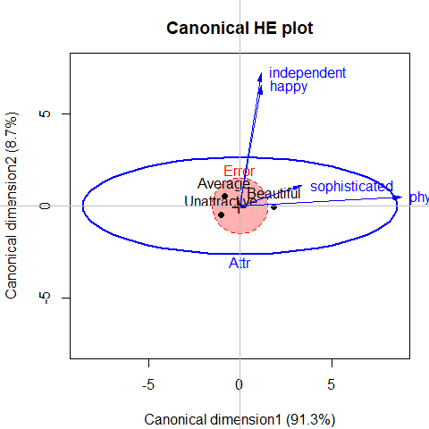

Figure 3.3: Canonical discriminant HE plot for the MockJury data. Variable vectors show the correlations of the predictors with the canonical dimensions.

```
#> Vector scale factor set to  8.8177
```

```r
heplot(jury.can,
       rev.axes = TRUE,
       fill = c(TRUE,FALSE),
       prefix="Canonical dimension",
       main="Canonical HE plot")
```

In this plot,

- the variable vectors are determined by the canonical structure coefficients and represent the correlations of the predictor variables with the canonical variables. Thus, an angle near zero with an axis represents a correlation close to 1.0; an angle near 90$^o$ represent a correlation close to 0.0. (The axes must be scaled to have equal unit lengths for angles to be interpretable.)
- The lengths of arrows are scaled to roughly fill the plot, but relative length represents the overall strength of the relation of the variable with the canonical dimensions.
- Points represent the means of the canonical scores on the two dimensions for the three groups of photos.

From this we can see that 91% of the variation among group means is accounted for by the first dimension, and this is nearly completely aligned with `phyattr`. The second dimension, accounting for the remaining 9% is determined nearly entirely by ratings on `happy` and `independent`. This display gives a relatively simple account of the results of the MANOVA and the relations of each of the ratings to discrimination among the photos.

## Main analysis

Proceeding to the main questions of interest, we carry out a two-way MANOVA of the responses `Years` and `Serious` in relation to the independent variables `Attr` and `Crime`.

```r
# influence of Attr of photo and nature of crime on Serious and Years
jury.mod2 <- lm( cbind(Serious, Years) ~ Attr * Crime, data=MockJury)
Anova(jury.mod2, test="Roy")
```

```
#>
#> Type II MANOVA Tests: Roy test statistic
#>            Df test stat approx F num Df den Df Pr(>F)
#> Attr        2    0.0756     4.08      2    108  0.020 *
#> Crime       1    0.0047     0.25      2    107  0.778
#> Attr:Crime  2    0.0501     2.71      2    108  0.071 .
#> ---
#> Signif. codes:  0 '***' 0.001 '**' 0.01 '*' 0.05 '.' 0.1 ' ' 1
```

We see that there is a nearly significant interaction between `Attr` and `Crime` and a strong effect of `Attr`.

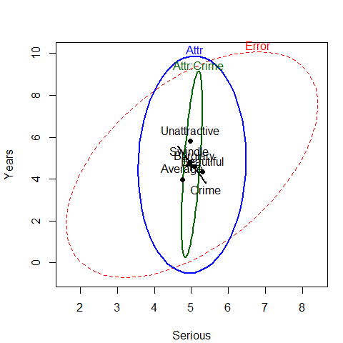

Figure 3.4: HE plot for the two-way MANOVA for `Years` and `Serious`

```r
heplot(jury.mod2)
```

The HE plot shows that the nearly significant interaction of `Attr:Crime` is mainly in terms of differences among the groups on the response of `Years` of sentence, with very little contribution of `Serious`. We explore this interaction in a bit more detail below. The main effect of `Attr` is also dominated by differences among groups on `Years`.

If we assume that `Years` of sentence is the main outcome of interest, it also makes sense to carry out a step-down test of this variable by itself, controlling for the rating of seriousness (`Serious`) of the crime. The model `jury.mod3` below is equivalent to an ANCOVA for `Years`.

```r
# stepdown test (ANCOVA), controlling for Serious
jury.mod3 <- lm( Years ~ Serious + Attr * Crime, data=MockJury)
t(coef(jury.mod3))
```

```
#>      (Intercept) Serious AttrAverage AttrUnattractive CrimeSwindle
#> [1,]    0.011612 0.83711     0.39586          0.60285     -0.26302
#>      AttrAverage:CrimeSwindle AttrUnattractive:CrimeSwindle
#> [1,]                 -0.53701                        2.5123
```

```r
Anova(jury.mod3)
```

```
#> Anova Table (Type II tests)
#>
#> Response: Years
#>            Sum Sq  Df F value  Pr(>F)
#> Serious       379   1   41.14 3.9e-09 ***
#> Attr           74   2    4.02   0.021 *
#> Crime           4   1    0.43   0.516
#> Attr:Crime     49   2    2.67   0.074 .
#> Residuals     987 107
#> ---
#> Signif. codes:  0 '***' 0.001 '**' 0.01 '*' 0.05 '.' 0.1 ' ' 1
```

Thus, even when adjusting for `Serious` rating, there is still a significant main effect of `Attr` of the photo, but also a hint of an interaction of `Attr` with `Crime`. The coefficient for `Serious` indicates that participants awarded 0.84 additional years of sentence for each 1 unit step on the scale of seriousness of crime.

A particularly useful method for visualizing the fitted effects in such univariate response models is provided by the `effects`. By default `allEffects()` calculates the predicted values for all high-order terms in a given model, and the `plot` method produces plots of these values for each term. The statements below produce Figure 3.5.

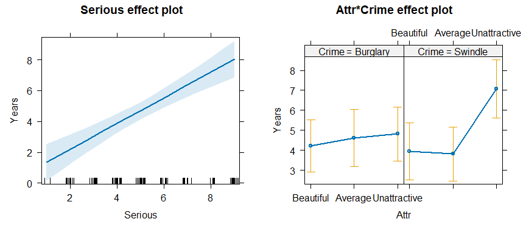

Figure 3.5: Effect plots for `Serious` and the `Attr * Crime` interaction in the ANCOVA model `jury.mod3`.

```r
library(effects)
jury.eff <- allEffects(jury.mod3)
plot(jury.eff, ask=FALSE)
```

The effect plot for `Serious` shows the expected linear relation between that variable and `Years`. Of greater interest here is the nature of the possible interaction of `Attr` and `Crime` on `Years` of sentence, controlling for `Serious`. The effect plot shows that for the crime of Swindle, there is a much greater `Years` of sentence awarded to Unattractive defendants.

# 4 Egyptian skulls from five epochs

This example examines physical measurements of size and shape made on 150 Egyptian skulls from five epochs ranging from 4000 BC to 150 AD. The measures are: maximal breadth (`mb`), basibregmatic height (`bh`), basialiveolar length (`bl`), and nasal height (`nh`) of each skull. See Figure 4.1 for a diagram. The question of interest is whether and how these measurements change over time. Systematic changes over time is of interest because this would indicate interbreeding with immigrant populations.

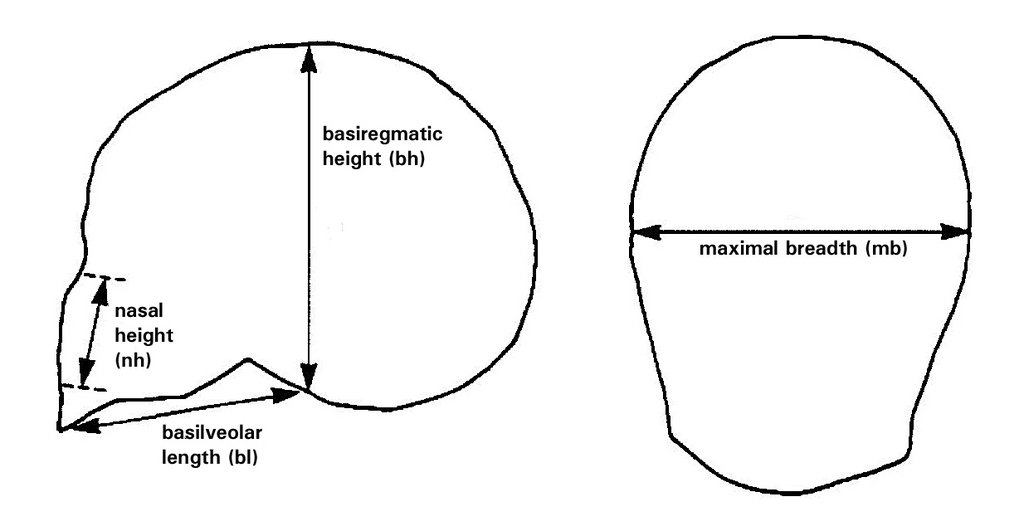

Figure 4.1: Diagram of the skull measurements. Maximal breadth and basibregmatic height are the basic measures of “size” of a skull. Basialveolar length and nasal height are important anthropometric measures of “shape”.

```r
data(Skulls)
str(Skulls)
```

```
#> 'data.frame':    150 obs. of  5 variables:
#>  $ epoch: Ord.factor w/ 5 levels "c4000BC"<"c3300BC"<..: 1 1 1 1 1 1 1 1 1 1 ...
#>  $ mb   : num  131 125 131 119 136 138 139 125 131 134 ...
#>  $ bh   : num  138 131 132 132 143 137 130 136 134 134 ...
#>  $ bl   : num  89 92 99 96 100 89 108 93 102 99 ...
#>  $ nh   : num  49 48 50 44 54 56 48 48 51 51 ...
```

```r
table(Skulls$epoch)
```

```
#>
#> c4000BC c3300BC c1850BC  c200BC  cAD150
#>      30      30      30      30      30
```

Note that `epoch` is an ordered factor, so the default contrasts will be orthogonal polynomials. This assumes that `epoch` values are equally spaced, which they are not. However, examining the linear and quadratic trends is useful to a first approximation.

For ease of labeling various outputs, it is useful to trim the `epoch` values and assign more meaningful variable labels.

```r
# make shorter labels for epochs
Skulls$epoch <- factor(Skulls$epoch, labels=sub("c","",levels(Skulls$epoch)))
# assign better variable labels
vlab <- c("maxBreadth", "basibHeight", "basialLength", "nasalHeight")
```

We start with some simple displays of the means by epoch. From the numbers, the means don’t seem to vary much.  
A `pairs` plot, Figure 4.2, joining points by `epoch` is somewhat more revealing for the bivariate relations among means.

```r
means <- aggregate(cbind(mb, bh, bl, nh) ~ epoch, data=Skulls, FUN=mean)[,-1]
rownames(means) <- levels(Skulls$epoch)
means
```

```
#>            mb     bh     bl     nh
#> 4000BC 131.37 133.60 99.167 50.533
#> 3300BC 132.37 132.70 99.067 50.233
#> 1850BC 134.47 133.80 96.033 50.567
#> 200BC  135.50 132.30 94.533 51.967
#> AD150  136.17 130.33 93.500 51.367
```

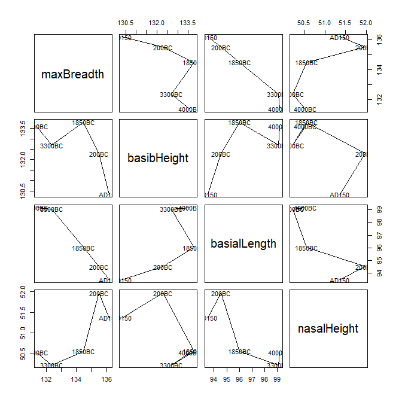

Figure 4.2: Pairs plot of means of Skulls data, by epoch.

```r
pairs(means, vlab,
      panel = function(x, y) {
          text(x, y, levels(Skulls$epoch))
          lines(x,y)
      })
```

Perhaps better for visualizing the trends over time is a set of boxplots, joining means over `epoch`. Using `bwplot()` from the `lattice` package requires reshaping the data from wide to long format. The following code produces Figure 4.3.

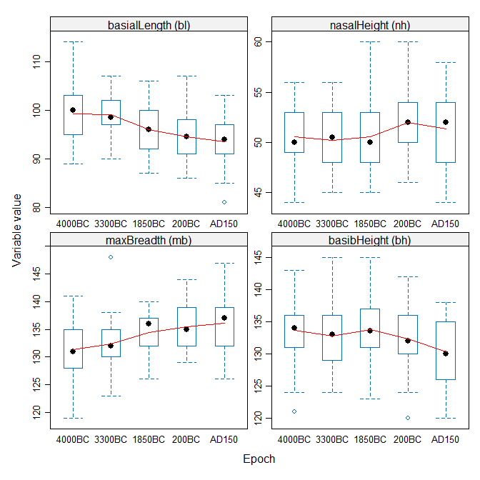

Figure 4.3: Boxplots of Skulls data, by epoch, for each variable.

```r
library(lattice)
library(reshape2)
sklong <- melt(Skulls, id="epoch")

bwplot(value ~ epoch | variable, data=sklong, scales="free",
    ylab="Variable value", xlab="Epoch",
    strip=strip.custom(factor.levels=paste(vlab,
                                           " (", levels(sklong$variable), ")",
                                           sep="")),
    panel = function(x,y, ...) {
        panel.bwplot(x, y, ...)
        panel.linejoin(x,y, col="red", ...)
    })
```

The trend lines aren’t linear, but neither are they random, so something systematic has been going on!

Now, fit the MANOVA model, and test the effect of `epoch` with `car::Anova()`. We see that the multivariate means differ substantially.

```r
# fit manova model
sk.mod <- lm(cbind(mb, bh, bl, nh) ~ epoch, data=Skulls)
Anova(sk.mod)
```

```
#>
#> Type II MANOVA Tests: Pillai test statistic
#>       Df test stat approx F num Df den Df  Pr(>F)
#> epoch  4     0.353     3.51     16    580 4.7e-06 ***
#> ---
#> Signif. codes:  0 '***' 0.001 '**' 0.01 '*' 0.05 '.' 0.1 ' ' 1
```

Perhaps of greater interest are the more focused tests of trends over time. These are based on tests of the coefficients in the model `sk.mod` being jointly equal to zero, for subsets of the (polynomial) contrasts in `epoch`.

```r
coef(sk.mod)
```

```
#>                    mb        bh        bl       nh
#> (Intercept) 133.97333 132.54667 96.460000 50.93333
#> epoch.L       4.02663  -2.19251 -5.017481  1.07517
#> epoch.Q      -0.46325  -1.26504 -0.089087  0.12472
#> epoch.C      -0.46380  -0.78003  1.075174 -0.83273
#> epoch^4       0.34263   0.80479 -0.661360 -0.41833
```

```r
coef(sk.mod)["epoch.L",]
```

```
#>      mb      bh      bl      nh
#>  4.0266 -2.1925 -5.0175  1.0752
```

```r
print(linearHypothesis(sk.mod, "epoch.L"), SSP=FALSE) # linear component
```

```
#>
#> Multivariate Tests:
#>                  Df test stat approx F num Df den Df    Pr(>F)
#> Pillai            1   0.29138   14.597      4    142 5.195e-10 ***
#> Wilks             1   0.70862   14.597      4    142 5.195e-10 ***
#> Hotelling-Lawley  1   0.41119   14.597      4    142 5.195e-10 ***
#> Roy               1   0.41119   14.597      4    142 5.195e-10 ***
#> ---
#> Signif. codes:  0 '***' 0.001 '**' 0.01 '*' 0.05 '.' 0.1 ' ' 1
```

`linearHypothesis()` can also be used to test composite hypotheses. Here we test all non-linear coefficients jointly. The result indicates that, collectively, all non-linear terms are not significantly different from zero.

```r
print(linearHypothesis(sk.mod, c("epoch.Q", "epoch.C", "epoch^4")), SSP=FALSE)
```

```
#>
#> Multivariate Tests:
#>                  Df test stat approx F num Df den Df Pr(>F)
#> Pillai            3   0.06819  0.83726     12 432.00 0.6119
#> Wilks             3   0.93296  0.83263     12 375.99 0.6167
#> Hotelling-Lawley  3   0.07063  0.82791     12 422.00 0.6216
#> Roy               3   0.04519  1.62676      4 144.00 0.1707
```

Again, HE plots can show the patterns of these tests of multivariate hypotheses. With four response variables, it is easiest to look at all pairwise HE plots with the `pairs.mlm()` function. The statement below produces Figure 4.4. In this plot, we show the hypothesis ellipsoids for the overall effect of `epoch`, as well as those for the tests just shown for the linear trend component `epoch.L` as well as the joint test of all non-linear terms.

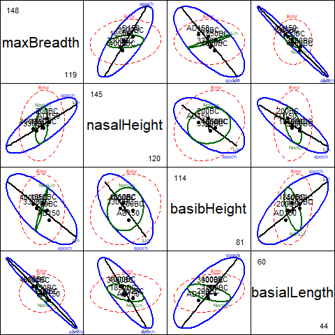

Figure 4.4: Pairs HE plot of Skulls data, showing multivariate tests of `epoch`, as well as tests of linear and nonlinear trends.

```r
pairs(sk.mod, variables=c(1,4,2,3),
    hypotheses=list(Lin="epoch.L",
                    NonLin=c("epoch.Q", "epoch.C", "epoch^4")),
    var.labels=vlab[c(1,4,2,3)])
```

These plots have an interesting geometric interpretation: the $\mathbf{H}$ ellipses for the overall effect of `epoch` are representations of the additive decomposition of this effect into  
$\mathbf{H}$ ellipses for the linear and nonlinear linear hypothesis tests according to

$$\mathbf{H}_{\textrm{epoch}} = \mathbf{H}_{\textrm{linear}} + \mathbf{H}_{\textrm{nonlinear}}$$

where the linear term has rank 1 (and so plots as a line), while the nonlinear term has rank 3. In each panel, it can be seen that the large direction of the $\mathbf{H}_{\textrm{epoch}}$ leading to significance of this effect corresponds essentially to the linear contrast. $\mathbf{H}_{\textrm{nonlinear}}$ is the orthogonal complement of $\mathbf{H}_{\textrm{linear}}$ in the space of $\mathbf{H}_{\textrm{epoch}}$, but nowhere does it protrude beyond the boundary of the $\mathbf{E}$ ellipsoid.

# References

Fox, J., Friendly, M., & Monette, G. (2009). Visualizing hypothesis tests in multivariate linear models: The *heplots* package for R. *Computational Statistics*, *24*(2), 233–246.

Friendly, M. (2006). Data ellipses, HE plots and reduced-rank displays for multivariate linear models: SAS software and examples. *Journal of Statistical Software*, *17*(6), 1–42.

Friendly, M. (2007). HE plots for multivariate general linear models. *Journal of Computational and Graphical Statistics*, *16*(2), 421–444.

Johnson, R., & Wichern, D. (1992). *Applied multivariate statistical analysis*. Englewood Cliffs, N.J: Prentice Hall.

Plaster, M. E. (1989). *The effect of defendent physical attractiveness on juridic decisions using felon inmates as mock jurors* (Unpublished master's thesis). East Carolina University, Greenville, NC.

Warne, F. T. (2014). A primer on multivariate analysis of variance(MANOVA) for behavioral scientists. *Practical Assessment, Research & Evaluation*, *19*(1).

[^1]: The data were made available courtesy of Karl Wuensch, from a website that no longer exists.